# 1_Cahyani Dyah Rofiana

Cahyani Dyah Rofiana

2023-12-16

Persiapan library

```r
library("forecast")
```

```r
library("graphics")
library("TTR")
library("TSA")
library(rio)
data<-import("https://raw.githubusercontent.com/CahyaniDyahRofiana/PraktikumUTSMPDW/main/Data1.csv")
data
```

```
##      No  Harga
## 1     1  56550
## 2     2  53200
## 3     3  48800
## 4     4  40450
## 5     5  58600
## 6     6  63200
## 7     7  53800
## 8     8  58750
## 9     9  55300
## 10   10  49500
## 11   11  54400
## 12   12  54650
## 13   13  54200
## 14   14  54000
```

[output cut: 125 more lines]

```r
View(data)
str(data)
```

```
## 'data.frame':    139 obs. of  2 variables:
##  $ No   : int  1 2 3 4 5 6 7 8 9 10 ...
##  $ Harga: int  56550 53200 48800 40450 58600 63200 53800 58750 55300 49500 ...
```

```r
dim(data)
```

```
## [1] 139   2
```

```r
data.ts <- ts(data$Harga)
data.ts
```

```
## Time Series:
## Start = 1
## End = 139
## Frequency = 1
##   [1]  56550  53200  48800  40450  58600  63200  53800  58750  55300  49500
##  [11]  54400  54650  54200  54000  51750  48000  39000  38400  53150  32100
##  [21]  27650  27300  26550  24200  24950  26850  25500  24750  32150  28150
##  [31]  26200  25300  22300  21200  20800  21400  22550  24300  28100  33950
##  [41]  36200  34400  33450  43200  48650  45650  48950  45150  49200  49450
##  [51]  42550  40400  37700  27600  32950  31750  29800  33200  35350  41750
##  [61]  49600  50800  49550  45200  42750  51500  34750  35600  48200  38150
##  [71]  45050  47750  59550  70550  82300  89700  85950  94000 102750  94500
##  [81]  79100  73500  71700  64700  60850  61100  79250  69750  64750  53500
##  [91]  54000  61100  50000  44400  41150  34750  34150  32800  34400  37850
## [101]  38900  35550  36650  49000  46950  43500  44450  47500  47250  45350
## [111]  53750  42900  42500  39850  45200  39050  34400  34650  44700  41650
## [121]  32300  32600  32750  33500  32950  33000  32250  32250  41700  41750
## [131]  34650  32900  35450  36250  35950  39050  42900  47350  38250
```

```r
summary(data.ts)
```

```
##    Min. 1st Qu.  Median    Mean 3rd Qu.    Max.
##   20800   33475   41750   44474   51150  102750
```

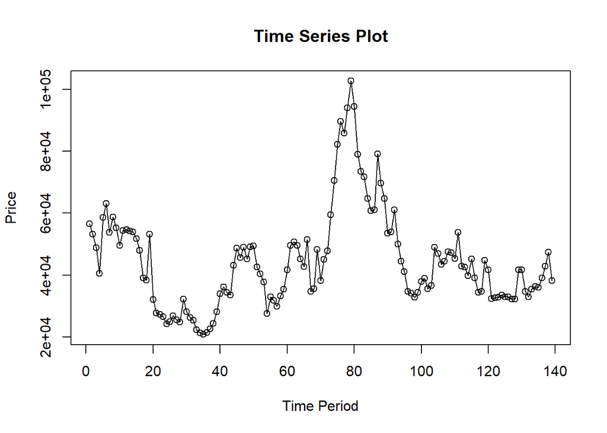

```r
ts.plot(data.ts, xlab="Time Period", ylab="Price",
        main = "Time Series Plot")
points(data.ts)
```

Single Moving Average & Double Moving Average

Pembagian Data

Pembagian data latih dan data uji dilakukan dengan perbandingan 80% data latih dan 20% data uji.

```r
#membagi data latih dan data uji
training_data <- data[1:111,]
testing_data <- data[112:139,]
train_data.ts <- ts(training_data$Harga)
test_data.ts <- ts(testing_data$Harga)
```

Eksplorasi Data

Eksplorasi data dilakukan pada keseluruhan data, data latih serta data uji menggunakan plot data deret waktu.

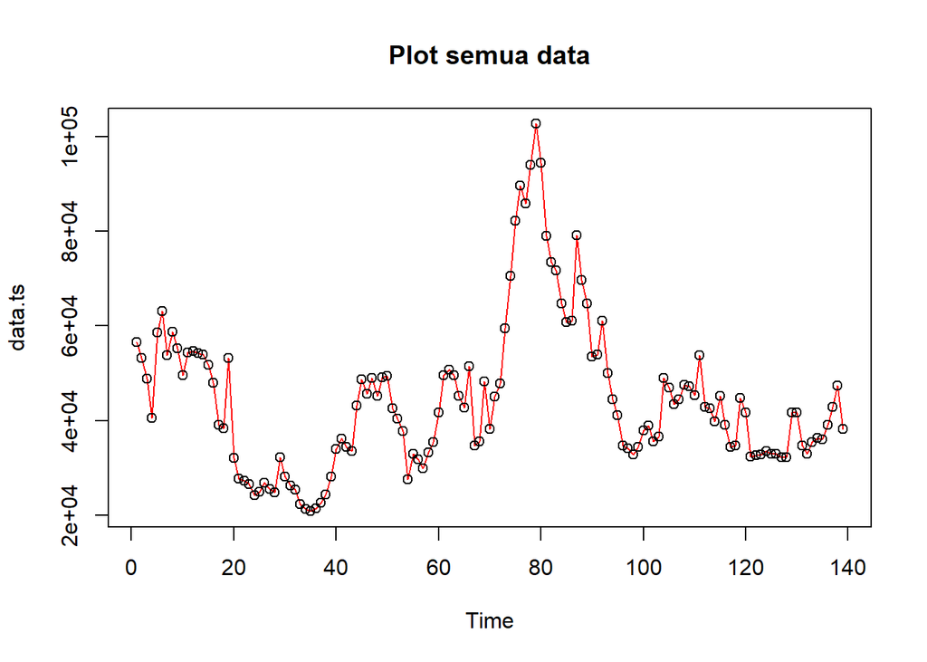

```r
#eksplorasi keseluruhan data
plot(data.ts, col="red",main="Plot semua data")
points(data.ts)
```

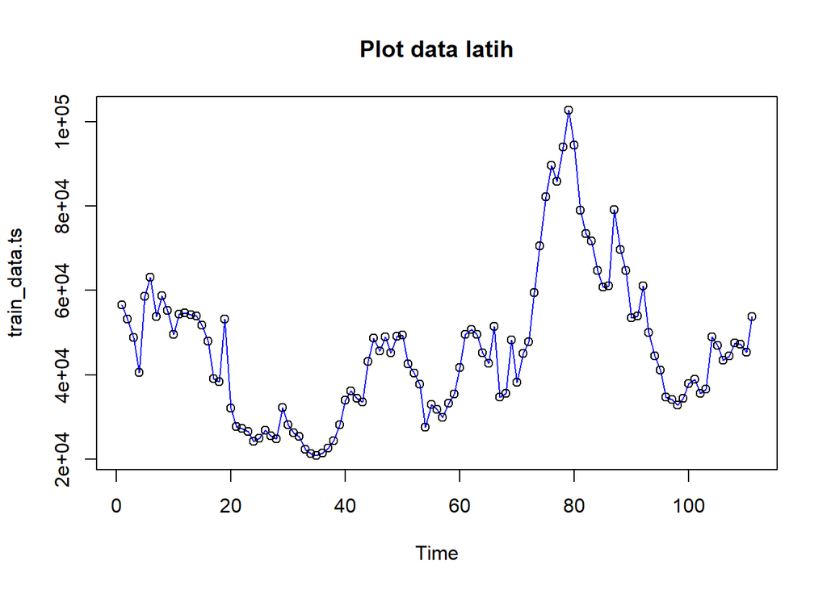

```r
#eksplorasi data latih
plot(train_data.ts, col="blue",main="Plot data latih")
points(train_data.ts)
```

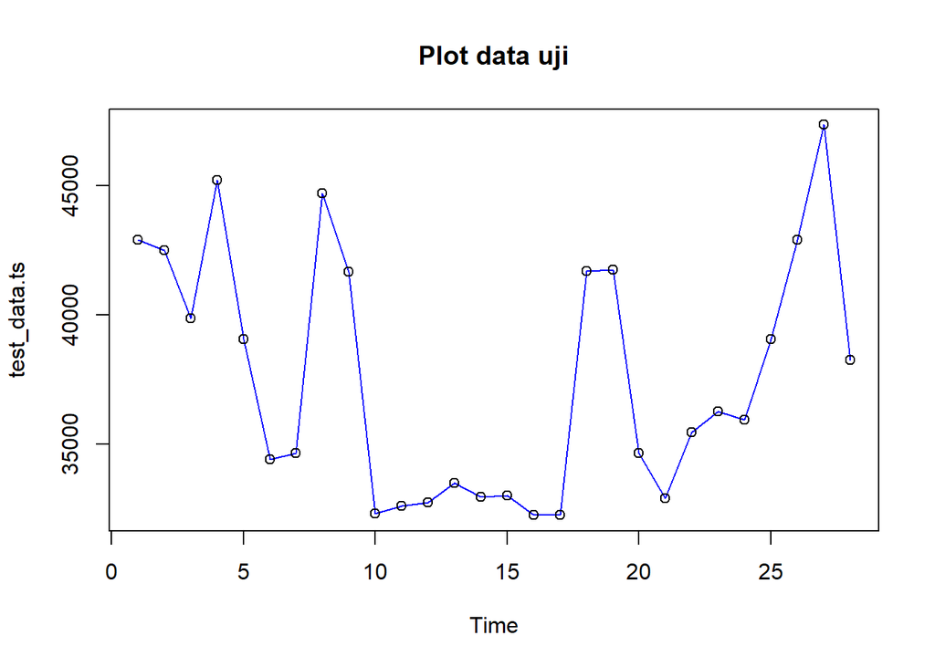

```r
#eksplorasi data uji
plot(test_data.ts, col="blue",main="Plot data uji")
points(test_data.ts)
```

Eksplorasi data juga dapat dilakukan menggunakan package ggplot2 dengan terlebih dahulu memanggil library package ggplot2.

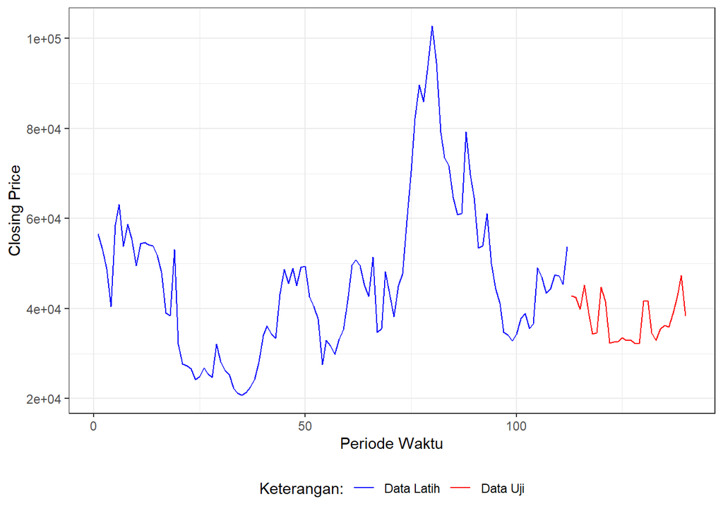

```r
#Eksplorasi dengan GGPLOT
library(ggplot2)
ggplot() +
  geom_line(data = training_data, aes(x = No, y = Harga, col = "Data Latih")) +
  geom_line(data = testing_data, aes(x = No, y = Harga, col = "Data Uji")) +
  labs(x = "Periode Waktu", y = "Closing Price", color = "Legend") +
  scale_colour_manual(name="Keterangan:", breaks = c("Data Latih", "Data Uji"),
                      values = c("blue", "red")) +
  theme_bw() + theme(legend.position = "bottom",
                     plot.caption = element_text(hjust=0.5, size=12))
```

### *Single Moving Average*

Ide dasar dari Single Moving Average (SMA) adalah data suatu periode dipengaruhi oleh data periode sebelumnya. Metode pemulusan ini cocok digunakan untuk pola data stasioner atau konstan. Prinsip dasar metode pemulusan ini adalah data pemulusan pada periode ke-t merupakan rata rata dari m buah data pada periode ke-t hingga periode ke (t-m+1). Data pemulusan pada periode ke-t selanjutnya digunakan sebagai nilai peramalan pada periode ke t+1

Pemulusan menggunakan metode SMA dilakukan dengan fungsi `SMA()`. Dalam hal ini akan dilakukan pemulusan dengan parameter `m=2`.

```r
data.sma<-SMA(train_data.ts, n=2)
data.sma
```

```
## Time Series:
## Start = 1
## End = 111
## Frequency = 1
##   [1]    NA 54875 51000 44625 49525 60900 58500 56275 57025 52400 51950 54525
##  [13] 54425 54100 52875 49875 43500 38700 45775 42625 29875 27475 26925 25375
##  [25] 24575 25900 26175 25125 28450 30150 27175 25750 23800 21750 21000 21100
##  [37] 21975 23425 26200 31025 35075 35300 33925 38325 45925 47150 47300 47050
##  [49] 47175 49325 46000 41475 39050 32650 30275 32350 30775 31500 34275 38550
##  [61] 45675 50200 50175 47375 43975 47125 43125 35175 41900 43175 41600 46400
##  [73] 53650 65050 76425 86000 87825 89975 98375 98625 86800 76300 72600 68200
##  [85] 62775 60975 70175 74500 67250 59125 53750 57550 55550 47200 42775 37950
##  [97] 34450 33475 33600 36125 38375 37225 36100 42825 47975 45225 43975 45975
## [109] 47375 46300 49550
```

Data pemulusan pada periode ke-t selanjutnya digunakan sebagai nilai peramalan pada periode ke t+1 sehingga hasil peramalan 1 periode kedepan adalah sebagai berikut.

```r
data.ramal<-c(NA,data.sma)
data.ramal #forecast 1 periode ke depan
```

```
##   [1]    NA    NA 54875 51000 44625 49525 60900 58500 56275 57025 52400 51950
##  [13] 54525 54425 54100 52875 49875 43500 38700 45775 42625 29875 27475 26925
##  [25] 25375 24575 25900 26175 25125 28450 30150 27175 25750 23800 21750 21000
##  [37] 21100 21975 23425 26200 31025 35075 35300 33925 38325 45925 47150 47300
##  [49] 47050 47175 49325 46000 41475 39050 32650 30275 32350 30775 31500 34275
##  [61] 38550 45675 50200 50175 47375 43975 47125 43125 35175 41900 43175 41600
##  [73] 46400 53650 65050 76425 86000 87825 89975 98375 98625 86800 76300 72600
##  [85] 68200 62775 60975 70175 74500 67250 59125 53750 57550 55550 47200 42775
##  [97] 37950 34450 33475 33600 36125 38375 37225 36100 42825 47975 45225 43975
## [109] 45975 47375 46300 49550
```

Selanjutnya akan dilakukan peramalan sejumlah data uji yaitu 28 periode. Pada metode SMA, hasil peramalan 28 periode ke depan akan bernilai sama dengan hasil peramalan 1 periode kedepan. Dalam hal ini akan dilakukan pengguabungan data aktual train, data hasil pemulusan dan data hasil ramalan 28 periode kedepan.

```r
data.gab<-cbind(aktual=c(train_data.ts,rep(NA,28)),pemulusan=c(data.sma,rep(NA,28)),ramalan=c(data.ramal,rep(data.ramal[length(data.ramal)],27)))
data.gab #forecast 28 periode ke depan
```

```
##        aktual pemulusan ramalan
##   [1,]  56550        NA      NA
##   [2,]  53200     54875      NA
##   [3,]  48800     51000   54875
##   [4,]  40450     44625   51000
##   [5,]  58600     49525   44625
##   [6,]  63200     60900   49525
##   [7,]  53800     58500   60900
##   [8,]  58750     56275   58500
##   [9,]  55300     57025   56275
##  [10,]  49500     52400   57025
##  [11,]  54400     51950   52400
##  [12,]  54650     54525   51950
##  [13,]  54200     54425   54525
##  [14,]  54000     54100   54425
```

[output cut: 125 more lines]

Adapun plot data deret waktu dari hasil peramalan yang dilakukan adalah sebagai berikut.

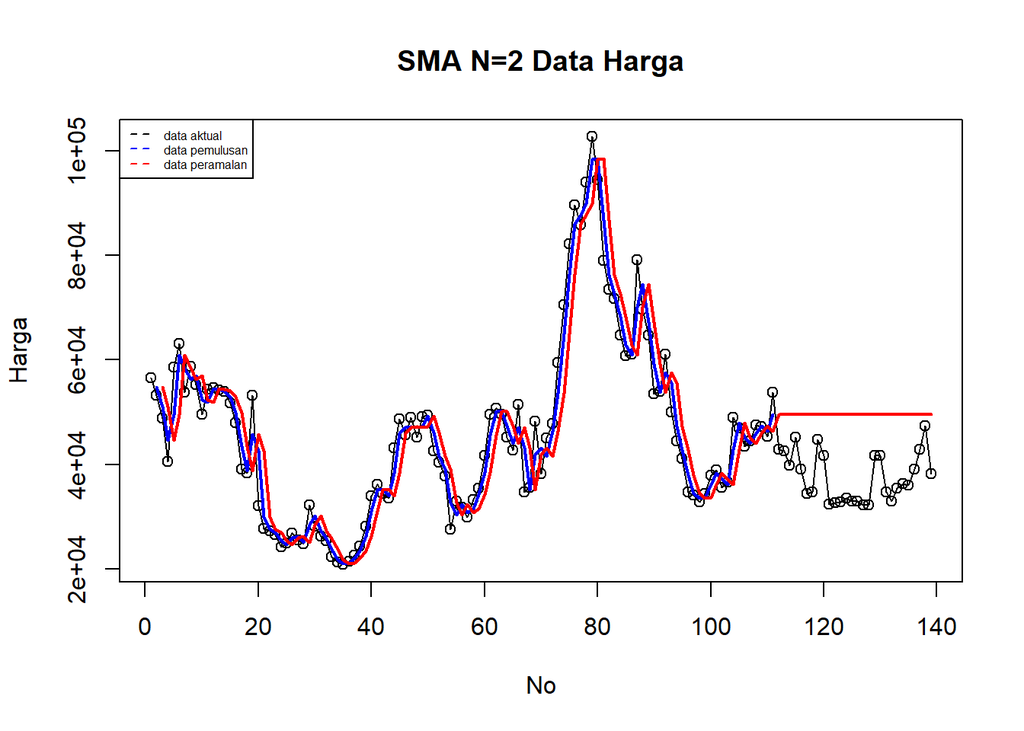

```r
ts.plot(data.ts, xlab="No", ylab="Harga", main= "SMA N=2 Data Harga")
points(data.ts)
lines(data.gab[,2],col="blue",lwd=2)
lines(data.gab[,3],col="red",lwd=2)
legend("topleft",c("data aktual","data pemulusan","data peramalan"), lty=8, col=c("black","blue","red"), cex=0.5)
```

Selanjutnya perhitungan akurasi dilakukan dengan ukuran akurasi *Sum Squares Error* (SSE), *Mean Square Error* (MSE) dan *Mean Absolute Percentage Error* (MAPE). Perhitungan akurasi dilakukan baik pada data latih maupun pada data uji.

```r
#Menghitung nilai keakuratan data latih
error_train.sma = train_data.ts-data.ramal[1:length(train_data.ts)]
SSE_train.sma = sum(error_train.sma[5:length(train_data.ts)]^2)
MSE_train.sma = mean(error_train.sma[5:length(train_data.ts)]^2)
MAPE_train.sma = mean(abs((error_train.sma[5:length(train_data.ts)]/train_data.ts[5:length(train_data.ts)])*100))

akurasi_train.sma <- matrix(c(SSE_train.sma, MSE_train.sma, MAPE_train.sma))
row.names(akurasi_train.sma)<- c("SSE", "MSE", "MAPE")
colnames(akurasi_train.sma) <- c("Akurasi m = 2")
akurasi_train.sma
```

```
##      Akurasi m = 2
## SSE   5.888964e+09
## MSE   5.503705e+07
## MAPE  1.219444e+01
```

```r
#Menghitung nilai keakuratan data uji
error_test.sma = test_data.ts-data.gab[112:139,3]
SSE_test.sma = sum(error_test.sma^2)
MSE_test.sma = mean(error_test.sma^2)
MAPE_test.sma = mean(abs((error_test.sma/test_data.ts*100)))

akurasi_test.sma <- matrix(c(SSE_test.sma, MSE_test.sma, MAPE_test.sma))
row.names(akurasi_test.sma)<- c("SSE", "MSE", "MAPE")
colnames(akurasi_test.sma) <- c("Akurasi m = 2")
akurasi_test.sma
```

```
##      Akurasi m = 2
## SSE   4.596760e+09
## MSE   1.641700e+08
## MAPE  3.372207e+01
```

Single Exponential Smoothing

Metode Exponential Smoothing adalah metode pemulusan dengan melakukan pembobotan menurun secara eksponensial. Nilai yang lebih baru diberi bobot yang lebih besar dari nilai terdahulu. Terdapat satu atau lebih parameter pemulusan yang ditentukan secara eksplisit, dan hasil pemilihan parameter tersebut akan menentukan bobot yang akan diberikan pada nilai pengamatan. Ada dua macam model, yaitu model tunggal dan ganda.

SES

Single Exponential Smoothing merupakan metode pemulusan yang tepat digunakan untuk data dengan pola stasioner atau konstan.

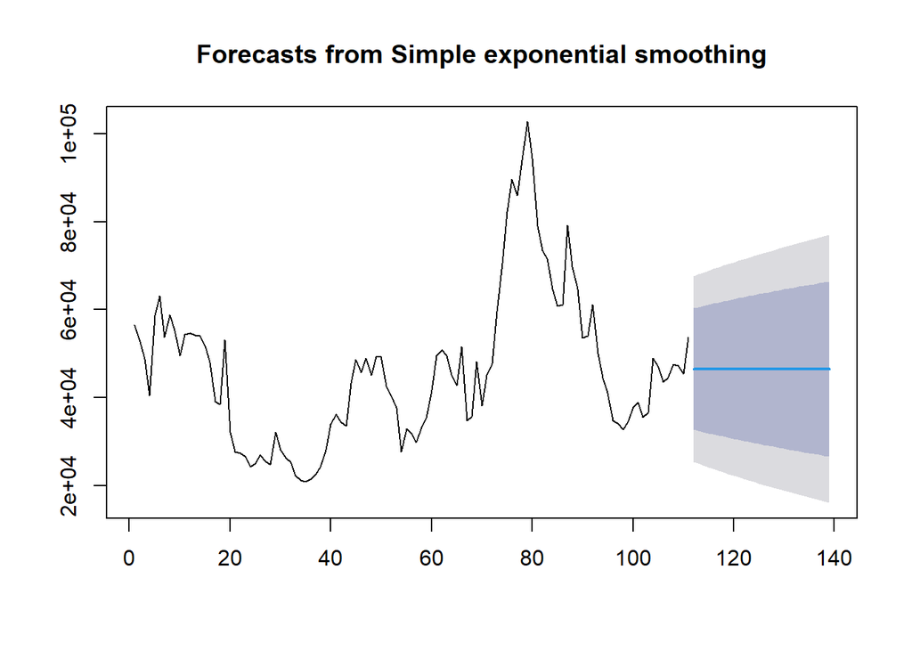

```r
#Cara 1 (fungsi ses)
ses.1 <- ses(train_data.ts, h = 28, alpha = 0.2)
plot(ses.1)
```

```r
ses.1
```

```
##     Point Forecast    Lo 80    Hi 80    Lo 95    Hi 95
## 112       46504.68 32692.62 60316.75 25380.96 67628.41
## 113       46504.68 32419.09 60590.28 24962.63 68046.74
## 114       46504.68 32150.77 60858.60 24552.26 68457.10
## 115       46504.68 31887.37 61122.00 24149.43 68859.94
## 116       46504.68 31628.64 61380.73 23753.73 69255.63
## 117       46504.68 31374.33 61635.04 23364.80 69644.57
## 118       46504.68 31124.22 61885.15 22982.30 70027.07
## 119       46504.68 30878.12 62131.25 22605.92 70403.45
## 120       46504.68 30635.83 62373.54 22235.37 70774.00
## 121       46504.68 30397.19 62612.18 21870.40 71138.97
## 122       46504.68 30162.03 62847.34 21510.75 71498.61
## 123       46504.68 29930.21 63079.16 21156.21 71853.16
## 124       46504.68 29701.59 63307.78 20806.56 72202.81
## 125       46504.68 29476.03 63533.34 20461.61 72547.76
## 126       46504.68 29253.42 63755.94 20121.16 72888.21
## 127       46504.68 29033.65 63975.71 19785.05 73224.32
## 128       46504.68 28816.61 64192.75 19453.12 73556.25
## 129       46504.68 28602.21 64407.16 19125.21 73884.16
## 130       46504.68 28390.33 64619.03 18801.18 74208.19
## 131       46504.68 28180.91 64828.46 18480.89 74528.47
## 132       46504.68 27973.86 65035.51 18164.23 74845.14
## 133       46504.68 27769.09 65240.28 17851.07 75158.30
## 134       46504.68 27566.54 65442.83 17541.29 75468.08
## 135       46504.68 27366.13 65643.24 17234.79 75774.58
## 136       46504.68 27167.80 65841.57 16931.47 76077.90
## 137       46504.68 26971.48 66037.89 16631.22 76378.14
## 138       46504.68 26777.11 66232.26 16333.97 76675.40
## 139       46504.68 26584.64 66424.72 16039.61 76969.76
```

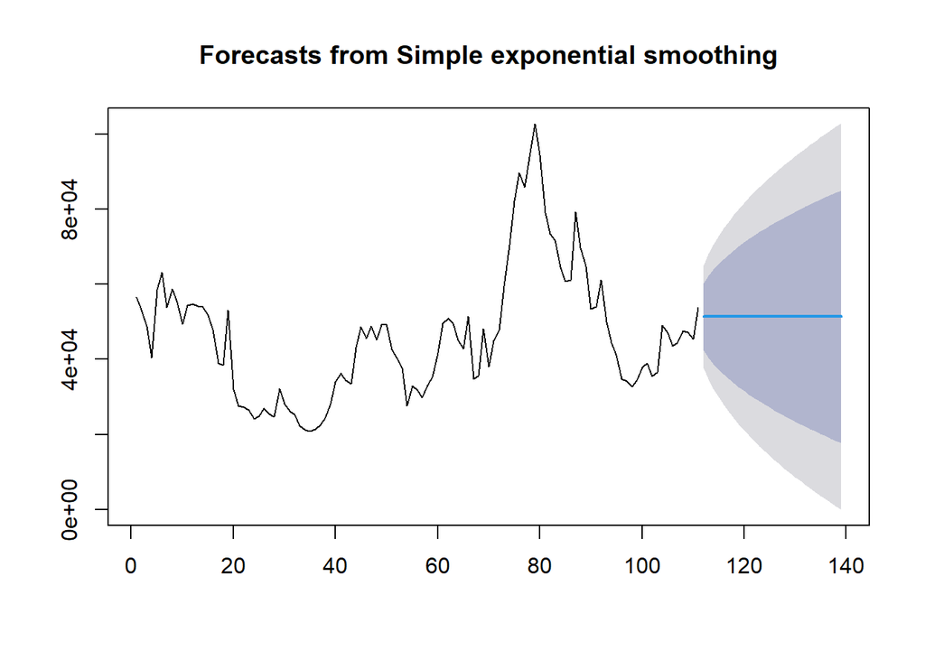

```r
ses.2<- ses(train_data.ts, h = 28, alpha = 0.7)
plot(ses.2)
```

```r
ses.2
```

```
##     Point Forecast    Lo 80    Hi 80       Lo 95     Hi 95
## 112       51382.88 42460.55 60305.22 37737.35462  65028.41
## 113       51382.88 40491.79 62273.98 34726.39270  68039.38
## 114       51382.88 38828.05 63937.72 32181.92223  70583.85
## 115       51382.88 37360.34 65405.43 29937.25127  72828.52
## 116       51382.88 36032.32 66733.44 27906.22765  74859.54
## 117       51382.88 34810.39 67955.38 26037.43818  76728.33
## 118       51382.88 33672.56 69093.21 24297.28166  78468.49
## 119       51382.88 32603.55 70162.22 22662.36722  80103.40
## 120       51382.88 31592.19 71173.57 21115.63579  81650.13
## 121       51382.88 30630.07 72135.70 19644.19240  83121.58
## 122       51382.88 29710.61 73055.15 18238.00846  84527.76
## 123       51382.88 28828.61 73937.16 16889.10188  85876.67
## 124       51382.88 27979.83 74785.94 15590.99616  87174.77
## 125       51382.88 27160.77 75605.00 14338.35046  88427.42
## 126       51382.88 26368.51 76397.26 13126.69894  89639.07
## 127       51382.88 25600.59 77165.18 11952.26233  90813.51
## 128       51382.88 24854.88 77910.88 10811.80865  91953.96
## 129       51382.88 24129.58 78636.19  9702.54828  93063.22
## 130       51382.88 23423.08 79342.69  8622.05361  94143.71
## 131       51382.88 22734.00 80031.77  7568.19645  95197.57
## 132       51382.88 22061.11 80704.66  6539.09875  96226.67
## 133       51382.88 21403.32 81362.45  5533.09332  97232.67
## 134       51382.88 20759.65 82006.12  4548.69205  98217.08
## 135       51382.88 20129.24 82636.53  3584.56012  99181.21
## 136       51382.88 19511.29 83254.47  2639.49475 100126.27
## 137       51382.88 18905.11 83860.66  1712.40760 101053.36
## 138       51382.88 18310.02 84455.74   802.31010 101963.46
## 139       51382.88 17725.46 85040.30   -91.69891 102857.47
```

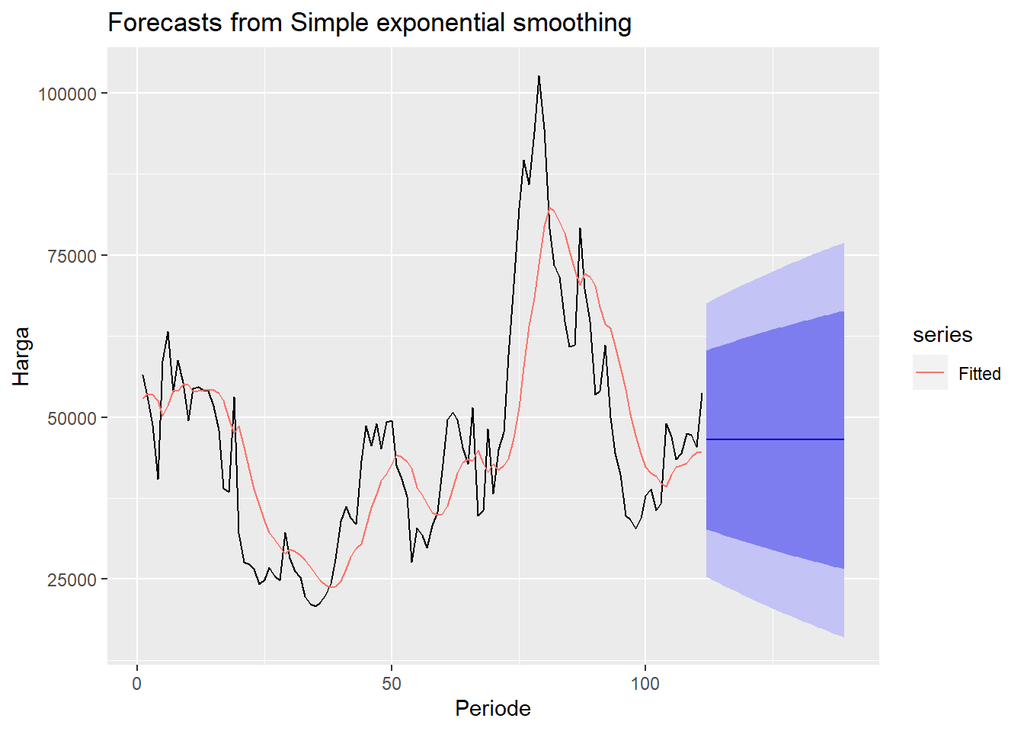

```r
autoplot(ses.1) +
  autolayer(fitted(ses.1), series="Fitted") +
  ylab("Harga") + xlab("Periode")
```

SES

Single Exponential Smoothing merupakan metode pemulusan yang tepat digunakan untuk data dengan pola stasioner atau konstan.

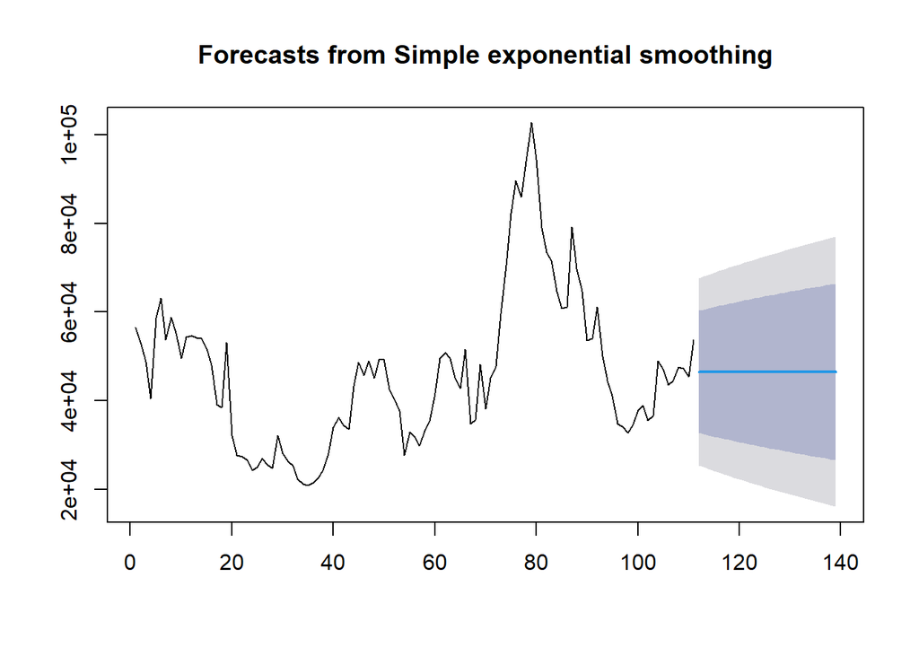

```r
#Cara 1 (fungsi ses)

ses.1 <- ses(train_data.ts, h = 28, alpha = 0.2)
plot(ses.1)
```

```r
ses.1
```

```
##     Point Forecast    Lo 80    Hi 80    Lo 95    Hi 95
## 112       46504.68 32692.62 60316.75 25380.96 67628.41
## 113       46504.68 32419.09 60590.28 24962.63 68046.74
## 114       46504.68 32150.77 60858.60 24552.26 68457.10
## 115       46504.68 31887.37 61122.00 24149.43 68859.94
## 116       46504.68 31628.64 61380.73 23753.73 69255.63
## 117       46504.68 31374.33 61635.04 23364.80 69644.57
## 118       46504.68 31124.22 61885.15 22982.30 70027.07
## 119       46504.68 30878.12 62131.25 22605.92 70403.45
## 120       46504.68 30635.83 62373.54 22235.37 70774.00
## 121       46504.68 30397.19 62612.18 21870.40 71138.97
## 122       46504.68 30162.03 62847.34 21510.75 71498.61
## 123       46504.68 29930.21 63079.16 21156.21 71853.16
## 124       46504.68 29701.59 63307.78 20806.56 72202.81
## 125       46504.68 29476.03 63533.34 20461.61 72547.76
## 126       46504.68 29253.42 63755.94 20121.16 72888.21
## 127       46504.68 29033.65 63975.71 19785.05 73224.32
## 128       46504.68 28816.61 64192.75 19453.12 73556.25
## 129       46504.68 28602.21 64407.16 19125.21 73884.16
## 130       46504.68 28390.33 64619.03 18801.18 74208.19
## 131       46504.68 28180.91 64828.46 18480.89 74528.47
## 132       46504.68 27973.86 65035.51 18164.23 74845.14
## 133       46504.68 27769.09 65240.28 17851.07 75158.30
## 134       46504.68 27566.54 65442.83 17541.29 75468.08
## 135       46504.68 27366.13 65643.24 17234.79 75774.58
## 136       46504.68 27167.80 65841.57 16931.47 76077.90
## 137       46504.68 26971.48 66037.89 16631.22 76378.14
## 138       46504.68 26777.11 66232.26 16333.97 76675.40
## 139       46504.68 26584.64 66424.72 16039.61 76969.76
```

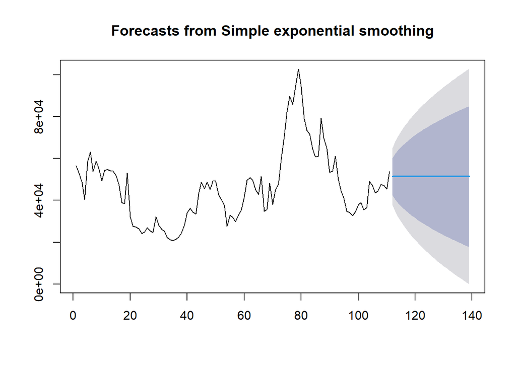

```r
ses.2<- ses(train_data.ts, h = 28, alpha = 0.7)
plot(ses.2)
```

```r
ses.2
```

```
##     Point Forecast    Lo 80    Hi 80       Lo 95     Hi 95
## 112       51382.88 42460.55 60305.22 37737.35462  65028.41
## 113       51382.88 40491.79 62273.98 34726.39270  68039.38
## 114       51382.88 38828.05 63937.72 32181.92223  70583.85
## 115       51382.88 37360.34 65405.43 29937.25127  72828.52
## 116       51382.88 36032.32 66733.44 27906.22765  74859.54
## 117       51382.88 34810.39 67955.38 26037.43818  76728.33
## 118       51382.88 33672.56 69093.21 24297.28166  78468.49
## 119       51382.88 32603.55 70162.22 22662.36722  80103.40
## 120       51382.88 31592.19 71173.57 21115.63579  81650.13
## 121       51382.88 30630.07 72135.70 19644.19240  83121.58
## 122       51382.88 29710.61 73055.15 18238.00846  84527.76
## 123       51382.88 28828.61 73937.16 16889.10188  85876.67
## 124       51382.88 27979.83 74785.94 15590.99616  87174.77
## 125       51382.88 27160.77 75605.00 14338.35046  88427.42
## 126       51382.88 26368.51 76397.26 13126.69894  89639.07
## 127       51382.88 25600.59 77165.18 11952.26233  90813.51
## 128       51382.88 24854.88 77910.88 10811.80865  91953.96
## 129       51382.88 24129.58 78636.19  9702.54828  93063.22
## 130       51382.88 23423.08 79342.69  8622.05361  94143.71
## 131       51382.88 22734.00 80031.77  7568.19645  95197.57
## 132       51382.88 22061.11 80704.66  6539.09875  96226.67
## 133       51382.88 21403.32 81362.45  5533.09332  97232.67
## 134       51382.88 20759.65 82006.12  4548.69205  98217.08
## 135       51382.88 20129.24 82636.53  3584.56012  99181.21
## 136       51382.88 19511.29 83254.47  2639.49475 100126.27
## 137       51382.88 18905.11 83860.66  1712.40760 101053.36
## 138       51382.88 18310.02 84455.74   802.31010 101963.46
## 139       51382.88 17725.46 85040.30   -91.69891 102857.47
```

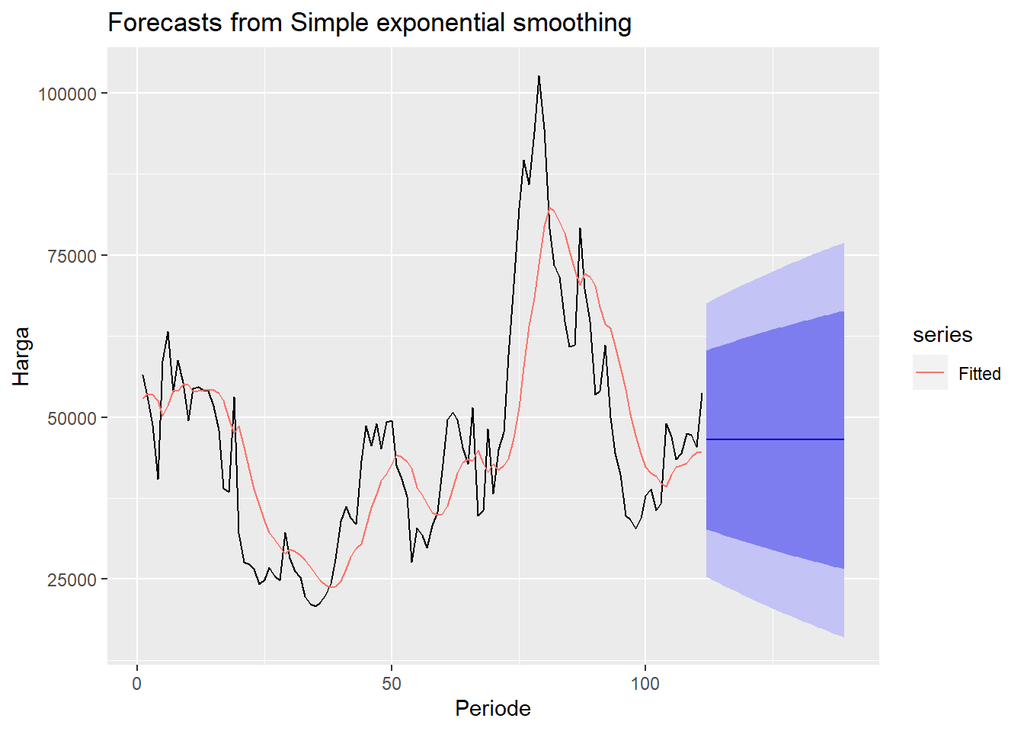

```r
autoplot(ses.1) +
  autolayer(fitted(ses.1), series="Fitted") +
  ylab("Harga") + xlab("Periode")
```

Pada fungsi ses() , terdapat beberapa argumen yang umum digunakan, yaitu nilia y , gamma , beta , alpha , dan h .

Nilai y adalah nilai data deret waktu, gamma adalah parameter pemulusan untuk komponen musiman, beta adalah parameter pemulusan untuk tren, dan alpha adalah parameter pemulusan untuk stasioner, serta h adalah banyaknya periode yang akan diramalkan.

Kasus di atas merupakan contoh inisialisasi nilai parameter $\lambda$ dengan nilai alpha 0,2 dan 0,7 dan banyak periode data yang akan diramalkan adalah sebanyak 28 periode. Selanjutnya akan digunakan fungsi HoltWinters() dengan nilai inisialisasi parameter dan panjang periode peramalan yang sama dengan fungsi ses() .

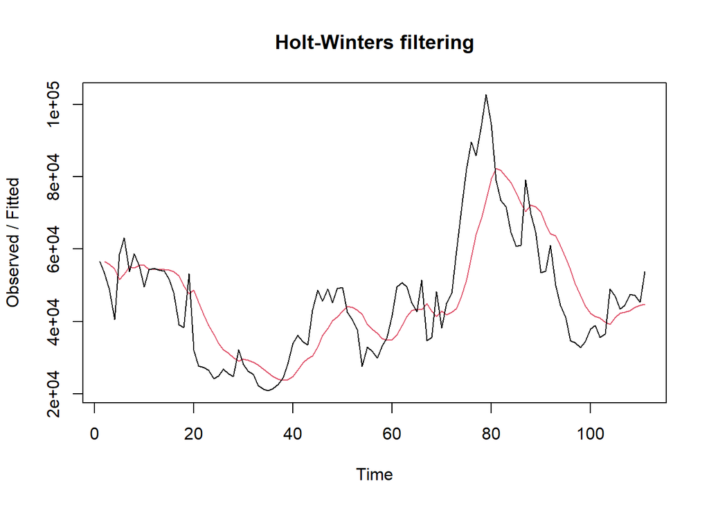

```r
#Cara 2 (fungsi Holtwinter)
ses1<- HoltWinters(train_data.ts, gamma = FALSE, beta = FALSE, alpha = 0.2)
plot(ses1)
```

```r
#ramalan
ramalan1<- forecast(ses1, h=28)
ramalan1
```

```
##     Point Forecast    Lo 80    Hi 80    Lo 95    Hi 95
## 112       46504.68 32684.32 60325.05 25368.26 67641.11
## 113       46504.68 32410.62 60598.75 24949.67 68059.70
## 114       46504.68 32142.14 60867.23 24539.06 68470.30
## 115       46504.68 31878.58 61130.79 24135.99 68873.38
## 116       46504.68 31619.69 61389.68 23740.06 69269.31
## 117       46504.68 31365.23 61644.14 23350.89 69658.48
## 118       46504.68 31114.97 61894.39 22968.15 70041.21
## 119       46504.68 30868.72 62140.64 22591.55 70417.82
## 120       46504.68 30626.29 62383.08 22220.78 70788.59
## 121       46504.68 30387.51 62621.86 21855.59 71153.78
## 122       46504.68 30152.21 62857.16 21495.73 71513.64
## 123       46504.68 29920.24 63089.12 21140.97 71868.40
## 124       46504.68 29691.48 63317.89 20791.11 72218.26
## 125       46504.68 29465.79 63543.58 20445.95 72563.42
## 126       46504.68 29243.05 63766.32 20105.29 72904.07
## 127       46504.68 29023.15 63986.22 19768.98 73240.39
## 128       46504.68 28805.98 64203.39 19436.85 73572.52
## 129       46504.68 28591.44 64417.93 19108.74 73900.63
## 130       46504.68 28379.44 64629.93 18784.52 74224.85
## 131       46504.68 28169.90 64839.47 18464.04 74545.32
## 132       46504.68 27962.72 65046.65 18147.19 74862.18
## 133       46504.68 27757.83 65251.54 17833.84 75175.53
## 134       46504.68 27555.15 65454.22 17523.88 75485.49
## 135       46504.68 27354.62 65654.75 17217.19 75792.18
## 136       46504.68 27156.17 65853.20 16913.69 76095.68
## 137       46504.68 26959.73 66049.64 16613.26 76396.11
## 138       46504.68 26765.25 66244.12 16315.83 76693.54
## 139       46504.68 26572.67 66436.70 16021.30 76988.07
```

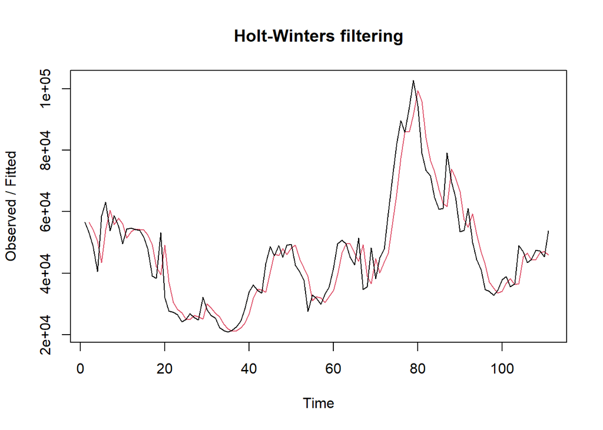

```r
ses2<- HoltWinters(train_data.ts, gamma = FALSE, beta = FALSE, alpha = 0.7)
plot(ses2)
```

```r
#ramalan
ramalan2<- forecast(ses2, h=28)
ramalan2
```

```
##     Point Forecast    Lo 80    Hi 80      Lo 95     Hi 95
## 112       51382.88 42458.95 60306.81 37734.9099  65030.86
## 113       51382.88 40489.84 62275.93 34723.4085  68042.36
## 114       51382.88 38825.80 63939.97 32178.4822  70587.29
## 115       51382.88 37357.83 65407.94 29933.4091  72832.36
## 116       51382.88 36029.57 66736.19 27902.0216  74863.75
## 117       51382.88 34807.42 67958.35 26032.8973  76732.87
## 118       51382.88 33669.39 69096.38 24292.4290  78473.34
## 119       51382.88 32600.18 70165.58 22657.2216  80108.55
## 120       51382.88 31588.65 71177.12 21110.2131  81655.55
## 121       51382.88 30626.35 72139.42 19638.5061  83127.26
## 122       51382.88 29706.73 73059.04 18232.0702  84533.70
## 123       51382.88 28824.57 73941.20 16882.9220  85882.85
## 124       51382.88 27975.63 74790.13 15584.5837  87181.18
## 125       51382.88 27156.43 75609.34 14331.7136  88434.05
## 126       51382.88 26364.03 76401.74 13119.8450  89645.92
## 127       51382.88 25595.97 77169.80 11945.1979  90820.57
## 128       51382.88 24850.13 77915.64 10804.5399  91961.23
## 129       51382.88 24124.69 78641.07  9695.0808  93070.69
## 130       51382.88 23418.07 79347.70  8614.3926  94151.38
## 131       51382.88 22728.87 80036.90  7560.3466  95205.42
## 132       51382.88 22055.86 80709.91  6531.0645  96234.70
## 133       51382.88 21397.95 81367.82  5524.8789  97240.89
## 134       51382.88 20754.17 82011.60  4540.3012  98225.47
## 135       51382.88 20123.64 82642.13  3575.9966  99189.77
## 136       51382.88 19505.58 83260.18  2630.7619 100135.01
## 137       51382.88 18899.29 83866.48  1703.5086 101062.26
## 138       51382.88 18304.10 84461.67   793.2481 101972.52
## 139       51382.88 17719.43 85046.33  -100.9211 102866.69
```

Fungsi HoltWinters memiliki argumen yang sama dengan fungsi ses() . Argumen-argumen kedua fungsi dapat dilihat lebih lanjut dengan ?ses() atau ?HoltWinters .

Nilai parameter $\alpha$ dari kedua fungsi dapat dioptimalkan menyesuaikan dari error-nya paling minimumnya. Caranya adalah dengan membuat parameter $\alpha =$ NULL .

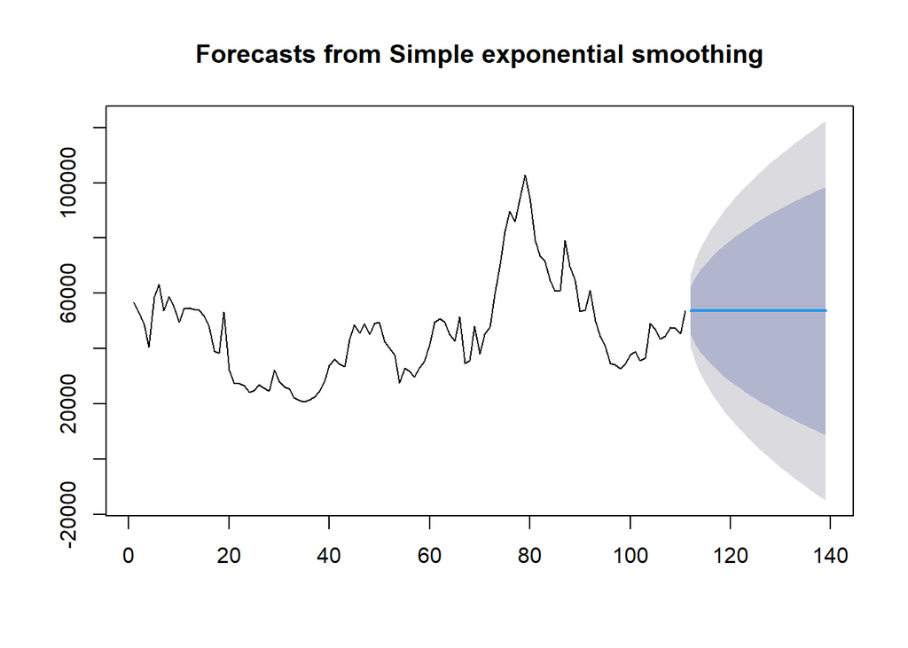

```r
#SES
ses.opt <- ses(train_data.ts, h = 28, alpha = NULL)
plot(ses.opt)
```

```r
ses.opt
```

```
##     Point Forecast     Lo 80    Hi 80       Lo 95     Hi 95
## 112        53648.8 45066.174 62231.43  40522.8049  66774.80
## 113        53648.8 41584.224 65713.38  35197.6229  72099.98
## 114        53648.8 38902.733 68394.87  31096.6353  76200.97
## 115        53648.8 36638.832 70658.77  27634.2977  79663.31
## 116        53648.8 34642.708 72654.90  24581.4897  82716.11
## 117        53648.8 32837.167 74460.44  21820.1536  85477.45
## 118        53648.8 31176.226 76121.38  19279.9634  88017.64
## 119        53648.8 29629.868 77667.74  16915.0127  90382.59
## 120        53648.8 28177.216 79120.39  14693.3725  92604.23
## 121        53648.8 26803.053 80494.55  12591.7721  94705.83
## 122        53648.8 25495.885 81801.72  10592.6304  96704.97
## 123        53648.8 24246.773 83050.83   8682.2797  98615.32
## 124        53648.8 23048.609 84248.99   6849.8454 100447.76
## 125        53648.8 21895.624 85401.98   5086.5065 102211.10
## 126        53648.8 20783.062 86514.54   3384.9904 103912.61
## 127        53648.8 19706.949 87590.65   1739.2175 105558.39
## 128        53648.8 18663.921 88633.68    144.0435 107153.56
## 129        53648.8 17651.102 89646.50  -1404.9298 108702.53
## 130        53648.8 16666.009 90631.59  -2911.4986 110209.10
## 131        53648.8 15706.484 91591.12  -4378.9656 111676.57
## 132        53648.8 14770.633 92526.97  -5810.2261 113107.83
## 133        53648.8 13856.786 93440.82  -7207.8347 114505.44
## 134        53648.8 12963.460 94334.14  -8574.0591 115871.66
## 135        53648.8 12089.332 95208.27  -9910.9231 117208.53
## 136        53648.8 11233.214 96064.39 -11220.2420 118517.85
## 137        53648.8 10394.038 96903.57 -12503.6513 119801.25
## 138        53648.8  9570.835 97726.77 -13762.6309 121060.23
## 139        53648.8  8762.727 98534.88 -14998.5249 122296.13
```

```r
#Lamda Optimum Holt Winter
sesopt<- HoltWinters(train_data.ts, gamma = FALSE, beta = FALSE,alpha = NULL)
sesopt
```

```
## Holt-Winters exponential smoothing without trend and without seasonal component.
##
## Call:
## HoltWinters(x = train_data.ts, alpha = NULL, beta = FALSE, gamma = FALSE)
##
## Smoothing parameters:
##  alpha: 0.9879308
##  beta : FALSE
##  gamma: FALSE
##
## Coefficients:
##      [,1]
## a 53648.9
```

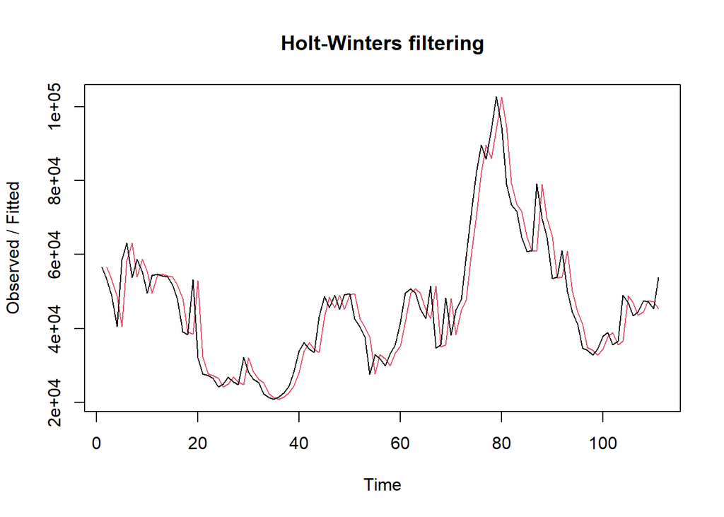

```r
plot(sesopt)
```

```r
#ramalan
ramalanopt<- forecast(sesopt, h=28)
ramalanopt
```

```
##     Point Forecast     Lo 80    Hi 80       Lo 95     Hi 95
## 112        53648.9 45066.335 62231.46  40523.0018  66774.79
## 113        53648.9 41584.345 65713.45  35197.7578  72100.03
## 114        53648.9 38902.831 68394.96  31096.7365  76201.05
## 115        53648.9 36638.915 70658.88  27634.3751  79663.42
## 116        53648.9 34642.779 72655.01  24581.5484  82716.24
## 117        53648.9 32837.228 74460.56  21820.1968  85477.59
## 118        53648.9 31176.278 76121.51  19279.9930  88017.80
## 119        53648.9 29629.912 77667.88  16915.0303  90382.76
## 120        53648.9 28177.253 79120.54  14693.3792  92604.41
## 121        53648.9 26803.083 80494.71  12591.7689  94706.02
## 122        53648.9 25495.909 81801.88  10592.6179  96705.17
## 123        53648.9 24246.792 83051.00   8682.2585  98615.53
## 124        53648.9 23048.622 84249.17   6849.8161 100447.98
## 125        53648.9 21895.632 85402.16   5086.4693 102211.32
## 126        53648.9 20783.065 86514.73   3384.9459 103912.85
## 127        53648.9 19706.948 87590.84   1739.1659 105558.63
## 128        53648.9 18663.915 88633.88    143.9852 107153.81
## 129        53648.9 17651.092 89646.70  -1404.9946 108702.79
## 130        53648.9 16665.995 90631.80  -2911.5696 110209.36
## 131        53648.9 15706.466 91591.33  -4379.0427 111676.83
## 132        53648.9 14770.611 92527.18  -5810.3091 113108.10
## 133        53648.9 13856.761 93441.03  -7207.9234 114505.71
## 134        53648.9 12963.431 94334.36  -8574.1533 115871.94
## 135        53648.9 12089.299 95208.49  -9911.0227 117208.81
## 136        53648.9 11233.178 96064.61 -11220.3468 118518.14
## 137        53648.9 10393.998 96903.79 -12503.7612 119801.55
## 138        53648.9  9570.793 97727.00 -13762.7458 121060.54
## 139        53648.9  8762.682 98535.11 -14998.6448 122296.44
```

Setelah dilakukan peramalan, akan dilakukan perhitungan keakuratan hasil peramalan. Perhitungan akurasi ini dilakukan baik pada data latih dan data uji.

Akurasi Data Latih

Perhitungan akurasi data dapat dilakukan dengan cara langsung maupun manual. Secara langsung, nilai akurasi dapat diambil dari objek yang tersimpan pada hasil SES, yaitu sum of squared errors (SSE). Nilai akurasi lain dapat dihitung pula dari nilai SSE tersebut.

```r
#Keakuratan Metode
#Pada data training
SSE1<-ses1$SSE
MSE1<-ses1$SSE/length(train_data.ts)
RMSE1<-sqrt(MSE1)

akurasi1 <- matrix(c(SSE1,MSE1,RMSE1))
row.names(akurasi1)<- c("SSE", "MSE", "RMSE")
colnames(akurasi1) <- c("Akurasi lamda=0.2")
akurasi1
```

```
##      Akurasi lamda=0.2
## SSE       1.269926e+10
## MSE       1.144078e+08
## RMSE      1.069616e+04
```

```r
SSE2<-ses2$SSE
MSE2<-ses2$SSE/length(train_data.ts)
RMSE2<-sqrt(MSE2)

akurasi2 <- matrix(c(SSE2,MSE2,RMSE2))
row.names(akurasi2)<- c("SSE", "MSE", "RMSE")
colnames(akurasi2) <- c("Akurasi lamda=0.7")
akurasi2
```

```
##      Akurasi lamda=0.7
## SSE       5.285759e+09
## MSE       4.761945e+07
## RMSE      6.900685e+03
```

```r
#Cara Manual
fitted1<-ramalan1$fitted
sisaan1<-ramalan1$residuals
head(sisaan1)
```

```
## Time Series:
## Start = 1
## End = 6
## Frequency = 1
## [1]        NA  -3350.00  -7080.00 -14014.00   6938.80  10151.04
```

```r
resid1<-training_data$Harga-ramalan1$fitted
head(resid1)
```

```
## Time Series:
## Start = 1
## End = 6
## Frequency = 1
## [1]        NA  -3350.00  -7080.00 -14014.00   6938.80  10151.04
```

```r
#Cara Manual
SSE.1=sum(sisaan1[2:length(train_data.ts)]^2)
SSE.1
```

```
## [1] 12699262240
```

```r
MSE.1 = SSE.1/length(train_data.ts)
MSE.1
```

```
## [1] 114407768
```

```r
MAPE.1 = sum(abs(sisaan1[2:length(train_data.ts)]/train_data.ts[2:length(train_data.ts)])*
               100)/length(train_data.ts)
MAPE.1
```

```
## [1] 18.94473
```

```r
akurasi.1 <- matrix(c(SSE.1,MSE.1,MAPE.1))
row.names(akurasi.1)<- c("SSE", "MSE", "MAPE")
colnames(akurasi.1) <- c("Akurasi lamda=0.2")
akurasi.1
```

```
##      Akurasi lamda=0.2
## SSE       1.269926e+10
## MSE       1.144078e+08
## MAPE      1.894473e+01
```

```r
fitted2<-ramalan2$fitted
sisaan2<-ramalan2$residuals
head(sisaan2)
```

```
## Time Series:
## Start = 1
## End = 6
## Frequency = 1
## [1]        NA -3350.000 -5405.000 -9971.500 15158.550  9147.565
```

```r
resid2<-training_data$Harga-ramalan2$fitted
head(resid2)
```

```
## Time Series:
## Start = 1
## End = 6
## Frequency = 1
## [1]        NA -3350.000 -5405.000 -9971.500 15158.550  9147.565
```

```r
SSE.2=sum(sisaan2[2:length(train_data.ts)]^2)
SSE.2
```

```
## [1] 5285759391
```

```r
MSE.2 = SSE.2/length(train_data.ts)
MSE.2
```

```
## [1] 47619454
```

```r
MAPE.2 = sum(abs(sisaan2[2:length(train_data.ts)]/train_data.ts[2:length(train_data.ts)])*
               100)/length(train_data.ts)
MAPE.2
```

```
## [1] 11.42711
```

```r
akurasi.2 <- matrix(c(SSE.2,MSE.2,MAPE.2))
row.names(akurasi.2)<- c("SSE", "MSE", "MAPE")
colnames(akurasi.2) <- c("Akurasi lamda=0.7")
akurasi.2
```

```
##      Akurasi lamda=0.7
## SSE       5.285759e+09
## MSE       4.761945e+07
## MAPE      1.142711e+01
```

Akurasi Data Uji

Akurasi data uji dapat dihitung dengan cara yang hampir sama dengan perhitungan akurasi data latih

```r
selisih1<-ramalan1$mean-testing_data$Harga
SSEtesting1<-sum(selisih1^2)
MSEtesting1<-SSEtesting1/length(testing_data)

selisih2<-ramalan2$mean-testing_data$Harga
SSEtesting2<-sum(selisih2^2)
MSEtesting2<-SSEtesting2/length(testing_data)

selisihopt<-ramalanopt$mean-testing_data$Harga
SSEtestingopt<-sum(selisihopt^2)
MSEtestingopt<-SSEtestingopt/length(testing_data)

akurasitesting1 <- matrix(c(SSEtesting1,SSEtesting2,SSEtestingopt))
row.names(akurasitesting1)<- c("SSE1", "SSE2", "SSEopt")
akurasitesting1
```

```
##              [,1]
## SSE1   2817896284
## SSE2   5917757451
## SSEopt 7810987254
```

```r
akurasitesting2 <- matrix(c(MSEtesting1,MSEtesting2,MSEtestingopt))
row.names(akurasitesting2)<- c("MSE1", "MSE2", "MSEopt")
akurasitesting2
```

```
##              [,1]
## MSE1   1408948142
## MSE2   2958878725
## MSEopt 3905493627
```

Selain dengan cara di atas, perhitungan nilai akurasi dapat menggunakan fungsi accuracy() dari package forecast . Penggunaannya yaitu dengan menuliskan accuracy(hasil ramalan, kondisi aktual) . Contohnya adalah sebagai berikut.

```r
#cara lain
accuracy(ramalanopt,testing_data$Close)
```

```
##                     ME     RMSE     MAE       MPE   MAPE     MASE        ACF1
## Training set -26.69587 6666.551 4954.12 -1.059494 10.708 1.001384 0.001233557
## Test set           NaN      NaN     NaN       NaN    NaN      NaN          NA
```